# (online food delivery platform Exploration)

## Preliminary Wrangling

> The document explores data for an online food delivery application, exploring about 1m orders for company's own delivery or pickup service offered in two weeks in march 2021 in 14 different cities of Malaysia. the data shows different attributes of the orders such as order id, payment type of the order, city and zone where the order was made and delivery type of the orders. The is information on the daily orders of the vendor as well as the amount of order for a specific order. whether the order was customers first order, whether the order was failed or successful as well as whether a voucher was used to complete the purchase are all gathered.

```python
# import all packages and set plots to be embedded inline
import numpy as np
import pandas as pd
import matplotlib.pyplot as plt
import seaborn as sb

%matplotlib inline
```

```python
df = pd.read_csv('fooddata.csv')
df.head()
```

|  | order_id | payment_type | city | zone | vendor_type | delivery_pickup | total_vendor_orders | total_amount | is_first_order | is_failed_order | is_voucher_used | expected_delivery_in_minutes | device | order_time |
| --- | --- | --- | --- | --- | --- | --- | --- | --- | --- | --- | --- | --- | --- | --- |
| 0 | 175893311 | Online Banking | Terengganu | Chukai | restaurants | delivery | 192.0 | 23.17 | False | False | False | 62 | mobile | 2021-03-05 20:27:10 UTC |
| 1 | 175893309 | Online Banking | Kedah | Sungai petani | restaurants | delivery | 147.0 | 30.11 | False | False | False | 60 | mobile | 2021-03-05 20:27:10 UTC |
| 2 | 175893304 | Online Banking | Klang valley | Ampang | restaurants | delivery | 2654.0 | 39.50 | False | False | False | 42 | mobile | 2021-03-05 20:27:10 UTC |
| 3 | 175893308 | Online Banking | NaN | NaN | restaurants | delivery | 752.0 | 131.98 | False | False | False | 30 | mobile | 2021-03-05 20:27:10 UTC |
| 4 | 175893305 | Online Banking | Klang valley | Tanjung karang halal | restaurants | delivery | 2701.0 | 16.99 | False | False | False | 20 | mobile | 2021-03-05 20:27:10 UTC |

```python
# high-level overview of data shape and composition
print(df.shape)
print(df.dtypes)
print(df.head(10))
```

```
(1048575, 14)
order_id                          int64
payment_type                     object
city                             object
zone                             object
vendor_type                      object
delivery_pickup                  object
total_vendor_orders             float64
total_amount                    float64
is_first_order                     bool
is_failed_order                    bool
is_voucher_used                    bool
expected_delivery_in_minutes      int64
device                           object
order_time                       object
dtype: object
    order_id      payment_type             city                  zone  \
0  175893311    Online Banking       Terengganu                Chukai
1  175893309    Online Banking            Kedah         Sungai petani
2  175893304    Online Banking     Klang valley                Ampang
3  175893308    Online Banking              NaN                   NaN
4  175893305    Online Banking     Klang valley  Tanjung karang halal
5  175893307  Cash On Delivery          Kuching          Kuching west
6  175893302  Cash On Delivery  Negeri Sembilan         Bandar enstek
7  175893318    Online Banking     Klang valley         Puchong utama
8  175893306  Cash On Delivery     Klang valley       Bukit beruntung
9  175893315    Online Banking     Klang valley                 Kapar

   vendor_type delivery_pickup  total_vendor_orders  total_amount  \
0  restaurants        delivery                192.0         23.17
1  restaurants        delivery                147.0         30.11
2  restaurants        delivery               2654.0         39.50
3  restaurants        delivery                752.0        131.98
4  restaurants        delivery               2701.0         16.99
5  restaurants        delivery                280.0         23.80
6  restaurants        delivery                777.0         19.83
7  restaurants        delivery                242.0         15.69
8  restaurants        delivery               2167.0         41.53
9  restaurants        delivery                118.0         29.29

```

[output cut: 8 more lines]

```
7           False            False            False
8           False            False            False
9           False             True            False

   expected_delivery_in_minutes  device               order_time
0                            62  mobile  2021-03-05 20:27:10 UTC
1                            60  mobile  2021-03-05 20:27:10 UTC
2                            42  mobile  2021-03-05 20:27:10 UTC
3                            30  mobile  2021-03-05 20:27:10 UTC
4                            20  mobile  2021-03-05 20:27:10 UTC
5                            35  mobile  2021-03-05 20:27:10 UTC
6                            20  mobile  2021-03-05 20:27:10 UTC
7                            48  mobile  2021-03-05 20:27:10 UTC
8                            50  mobile  2021-03-05 20:27:10 UTC
9                            48  mobile  2021-03-05 20:27:10 UTC
```

```python
#checking the duplicates and unique values
df.duplicated().sum()
```

```
0
```

```python
df.nunique()
```

```
order_id                        1048575
payment_type                          5
city                                 14
zone                                531
vendor_type                          22
delivery_pickup                       2
total_vendor_orders                9990
total_amount                      15273
is_first_order                        2
is_failed_order                       2
is_voucher_used                       2
expected_delivery_in_minutes        126
device                                3
order_time                       130079
dtype: int64
```

```python
df.delivery_pickup.value_counts()
```

```
delivery    1022698
pickup        25877
Name: delivery_pickup, dtype: int64
```

```python
# exploring the pickup orders
df[df.delivery_pickup =='pickup']
```

|  | order_id | payment_type | city | zone | vendor_type | delivery_pickup | total_vendor_orders | total_amount | is_first_order | is_failed_order | is_voucher_used | expected_delivery_in_minutes | device | order_time |
| --- | --- | --- | --- | --- | --- | --- | --- | --- | --- | --- | --- | --- | --- | --- |
| 30 | 175893319 | Online Banking | NaN | NaN | restaurants | pickup | 121.0 | 7.20 | False | False | False | 9 | mobile | 2021-03-05 20:27:11 UTC |
| 51 | 175893350 | Online Card Payment | NaN | NaN | restaurants | pickup | 4003.0 | 96.36 | False | False | False | 5 | mobile | 2021-03-05 20:27:12 UTC |
| 117 | 175893436 | Online Card Payment | NaN | NaN | restaurants | pickup | 1427.0 | 10.28 | False | False | True | 15 | mobile | 2021-03-05 20:27:15 UTC |
| 175 | 175893499 | Online Banking | NaN | NaN | restaurants | pickup | 464.0 | 21.65 | False | False | False | 14 | mobile | 2021-03-05 20:27:19 UTC |
| 225 | 175893556 | Online Banking | NaN | NaN | restaurants | pickup | 1022.0 | 31.98 | False | False | False | 19 | mobile | 2021-03-05 20:27:23 UTC |
| ... | ... | ... | ... | ... | ... | ... | ... | ... | ... | ... | ... | ... | ... | ... |
| 1048368 | 178753592 | Online Card Payment | NaN | NaN | restaurants | pickup | 8284.0 | 0.10 | False | False | False | 7 | mobile | 2021-03-11 09:05:10 UTC |
| 1048372 | 178753594 | Online Banking | NaN | NaN | restaurants | pickup | 416.0 | 9.52 | False | False | False | 9 | mobile | 2021-03-11 09:05:10 UTC |
| 1048498 | 178753745 | Online Banking | NaN | NaN | restaurants | pickup | 644.0 | 16.00 | False | False | False | 11 | mobile | 2021-03-11 09:05:36 UTC |
| 1048536 | 178753780 | Online Card Payment | NaN | NaN | restaurants | pickup | 746.0 | 8.90 | False | False | False | 10 | mobile | 2021-03-11 09:05:43 UTC |
| 1048570 | 178753819 | Online Card Payment | NaN | NaN | groceries | pickup | 81.0 | 29.60 | False | False | True | 5 | mobile | 2021-03-11 09:05:49 UTC |

25877 rows × 14 columns

- cite and zone were not recorder for pickups

```python
df.isnull().sum()
```

```
order_id                            0
payment_type                        0
city                            33220
zone                            33254
vendor_type                         0
delivery_pickup                     0
total_vendor_orders               406
total_amount                        0
is_first_order                      0
is_failed_order                     0
is_voucher_used                     0
expected_delivery_in_minutes        0
device                          27346
order_time                          0
dtype: int64
```

```python
df.shape
```

```
(1048575, 14)
```

```python
# 'total vendors orders' column name is misleading, it is the total number of daily orders the vendors received in the time window
df.rename(columns={"total_vendor_orders": "vendor_daily_order_number"}, inplace=True)
```

```python
df.dtypes
```

```
order_id                          int64
payment_type                     object
city                             object
zone                             object
vendor_type                      object
delivery_pickup                  object
vendor_daily_order_number       float64
total_amount                    float64
is_first_order                     bool
is_failed_order                    bool
is_voucher_used                    bool
expected_delivery_in_minutes      int64
device                           object
order_time                       object
dtype: object
```

```python
# fixing unit of time.
df['order_time'] = pd.to_datetime(df['order_time'])
```

```python
df.sample(20)
```

|  | order_id | payment_type | city | zone | vendor_type | delivery_pickup | vendor_daily_order_number | total_amount | is_first_order | is_failed_order | is_voucher_used | expected_delivery_in_minutes | device | order_time |
| --- | --- | --- | --- | --- | --- | --- | --- | --- | --- | --- | --- | --- | --- | --- |
| 228705 | 176158536 | Online Banking | Negeri Sembilan | Senawang | restaurants | delivery | 130.0 | 21.00 | False | False | False | 32 | mobile | 2021-03-06 13:17:23+00:00 |
| 653366 | 179975231 | Cash On Delivery | Penang | Bukit mertajam halal | restaurants | delivery | 2143.0 | 16.97 | False | False | False | 26 | mobile | 2021-03-13 12:06:54+00:00 |
| 696695 | 180025893 | Online Card Payment | Negeri Sembilan | Seremban halal | restaurants | delivery | 4089.0 | 47.29 | False | False | False | 35 | mobile | 2021-03-13 13:04:04+00:00 |
| 366086 | 178514099 | Cash On Delivery | Klang valley | Kota kemuning | restaurants | delivery | 1411.0 | 30.31 | False | False | False | 44 | mobile | 2021-03-10 17:08:08+00:00 |
| 269937 | 178403270 | Cash On Delivery | Sabah | Sepanggar halal | restaurants | delivery | 4618.0 | 24.43 | False | False | False | 36 | mobile | 2021-03-10 13:54:52+00:00 |
| 796708 | 174528671 | Cash On Delivery | Pahang | Bandar indera mahkota halal | restaurants | delivery | 409.0 | 32.81 | False | False | False | 45 | NaN | 2021-03-03 15:12:36+00:00 |
| 247359 | 178377402 | Cash On Delivery | Melaka | Masjid tanah | restaurants | delivery | 627.0 | 25.56 | False | False | False | 17 | mobile | 2021-03-10 13:20:50+00:00 |
| 434425 | 178605281 | Online Card Payment | Klang valley | Balakong | restaurants | delivery | 789.0 | 22.71 | False | False | False | 41 | mobile | 2021-03-10 19:09:07+00:00 |
| 802148 | 174535044 | Cash On Delivery | Klang valley | Ampang | restaurants | delivery | 1080.0 | 47.29 | False | False | False | 30 | mobile | 2021-03-03 15:23:22+00:00 |
| 470492 | 178646779 | Online Card Payment | Terengganu | Chukai halal | restaurants | delivery | 4806.0 | 36.94 | False | False | False | 43 | mobile | 2021-03-10 19:59:23+00:00 |
| 315274 | 178455509 | Online Card Payment | Klang valley | Klcc | restaurants | delivery | 324.0 | 30.63 | False | False | False | 22 | mobile | 2021-03-10 15:17:44+00:00 |
| 79671 | 175986680 | Cash On Delivery | Klang valley | Bandar seri putra | restaurants | delivery | 1207.0 | 25.67 | False | False | True | 12 | mobile | 2021-03-06 09:01:43+00:00 |
| 179697 | 176101969 | Online Card Payment | Klang valley | Puchong utama | restaurants | delivery | 645.0 | 12.67 | False | False | False | 17 | mobile | 2021-03-06 12:16:19+00:00 |
| 859414 | 174603009 | Online Banking | Johor | Pasir gudang | darkstores | delivery | 9392.0 | 4.15 | False | False | True | 27 | mobile | 2021-03-03 17:25:11+00:00 |
| 715558 | 180047622 | Online Banking | Klang valley | Subang | restaurants | delivery | 232.0 | 15.40 | False | False | False | 27 | mobile | 2021-03-13 13:29:53+00:00 |
| 484035 | 178662817 | Cash On Delivery | Klang valley | Klcc halal | restaurants | delivery | 1732.0 | 55.68 | False | False | False | 17 | mobile | 2021-03-10 20:17:23+00:00 |
| 907958 | 174660389 | Cash On Delivery | Klang valley | Kota kemuning | restaurants | delivery | 331.0 | 74.59 | False | False | False | 49 | mobile | 2021-03-03 18:43:34+00:00 |
| 360883 | 178508050 | Cash On Delivery | Klang valley | Jenjarom | restaurants | delivery | 89.0 | 16.17 | False | False | False | 7 | mobile | 2021-03-10 16:56:17+00:00 |
| 309875 | 178449300 | Cash On Delivery | Penang | Jelutong | supermarket | delivery | 1010.0 | 37.95 | False | False | True | 28 | mobile | 2021-03-10 15:07:19+00:00 |
| 710025 | 180041183 | Online Banking | Klang valley | Banting | restaurants | delivery | 1274.0 | 22.30 | False | False | False | 15 | mobile | 2021-03-13 13:22:04+00:00 |

```python
# extracting "hour" of order time as that will be the main variable needed for this analysis.
df['order_hour'] = df.order_time.dt.hour
```

```python
df.head()
```

|  | order_id | payment_type | city | zone | vendor_type | delivery_pickup | vendor_daily_order_number | total_amount | is_first_order | is_failed_order | is_voucher_used | expected_delivery_in_minutes | device | order_time | order_hour |
| --- | --- | --- | --- | --- | --- | --- | --- | --- | --- | --- | --- | --- | --- | --- | --- |
| 0 | 175893311 | Online Banking | Terengganu | Chukai | restaurants | delivery | 192.0 | 23.17 | False | False | False | 62 | mobile | 2021-03-05 20:27:10+00:00 | 20 |
| 1 | 175893309 | Online Banking | Kedah | Sungai petani | restaurants | delivery | 147.0 | 30.11 | False | False | False | 60 | mobile | 2021-03-05 20:27:10+00:00 | 20 |
| 2 | 175893304 | Online Banking | Klang valley | Ampang | restaurants | delivery | 2654.0 | 39.50 | False | False | False | 42 | mobile | 2021-03-05 20:27:10+00:00 | 20 |
| 3 | 175893308 | Online Banking | NaN | NaN | restaurants | delivery | 752.0 | 131.98 | False | False | False | 30 | mobile | 2021-03-05 20:27:10+00:00 | 20 |
| 4 | 175893305 | Online Banking | Klang valley | Tanjung karang halal | restaurants | delivery | 2701.0 | 16.99 | False | False | False | 20 | mobile | 2021-03-05 20:27:10+00:00 | 20 |

```python
df.describe()
```

|  | order_id | vendor_daily_order_number | total_amount | expected_delivery_in_minutes | order_hour |
| --- | --- | --- | --- | --- | --- |
| count | 1.048575e+06 | 1.048169e+06 | 1.048575e+06 | 1.048575e+06 | 1.048575e+06 |
| mean | 1.773706e+08 | 1.505370e+03 | 2.718966e+01 | 2.981744e+01 | 1.510479e+01 |
| std | 2.037832e+06 | 1.759352e+03 | 2.110785e+01 | 2.502135e+01 | 4.054287e+00 |
| min | 1.744504e+08 | 1.000000e+01 | 0.000000e+00 | 0.000000e+00 | 0.000000e+00 |
| 25% | 1.759152e+08 | 3.240000e+02 | 1.520000e+01 | 2.000000e+01 | 1.200000e+01 |
| 50% | 1.784160e+08 | 8.610000e+02 | 2.200000e+01 | 2.800000e+01 | 1.500000e+01 |
| 75% | 1.787318e+08 | 1.973000e+03 | 3.276000e+01 | 3.700000e+01 | 1.900000e+01 |
| max | 1.800643e+08 | 9.999000e+03 | 4.328410e+03 | 2.213200e+04 | 2.300000e+01 |

### What is the structure of your dataset?

> there is about 1m food orders for an online application, operating in 14 different cities in Malaysia, the payment was done either CoD or online, devices used to place orders were mobile, tablet and desktop. the status of orders that if the order was successful or failed. the voucher usage indicates whether they used voucher to make the purchase or not. and data for customer preferrence over delivery or pickup has also been gathered, city and zone of the orderes that completed through pick up has not been recorded.

### What is/are the main feature(s) of interest in your dataset?

> I would like to find out what the main channel of revenue is among all vendor types Also need to explore the difference of customer behaviour in those types. After figuring our what the main channel of revenue is I would like to see what the orders trend is during different hours in a day for that particular channel, and figure out what the indicating factors are in determining failure/success of the order out of variables expected delivery time and delivery/pickup modes.

### What features in the dataset do you think will help support your investigation into your feature(s) of interest?

> I expect that lunch has the most number of orders. the more the expected delivery time the more failure is and I assume customers who prefer to pick up their orders have higher successful rate as opposed to those who prefer their meals to be delievred.

## Univariate Exploration

> In this section, I will investigate distributions of vendor types, and customer behaviour in those channels.

```python
 df['vendor_type'].value_counts()
```

```
restaurants             1004601
darkstores                22382
convenience               10045
supermarket                4179
groceries                  2617
health_and_wellness        2273
electronics                1220
snacks_and_sweets           369
bakery                      353
pets                        198
drinks                      137
home_based_kitchen           90
beauty                       27
flowers                      25
games                        11
home_and_gifts               11
fashion                      11
stationery_and_books         10
mother_and_baby               9
party_supplies                5
sports_and_lifestyle          1
vouchers                      1
Name: vendor_type, dtype: int64
```

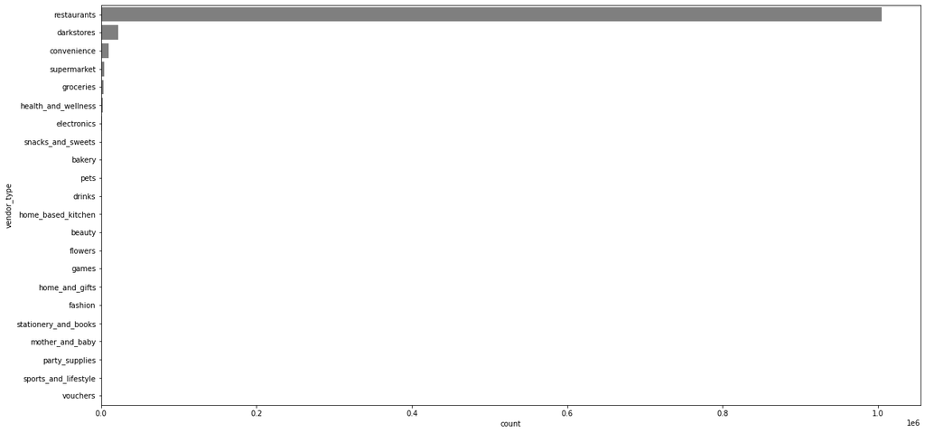

```python
# to find out the number of orders each vendor type genertaed I will plota seaborn count plot of numbers of orders generated through each channel.

plt.figure(figsize = [20,10])

color = sb.color_palette()[7]
vendor_order = df['vendor_type'].value_counts().index
sb.countplot (data=df, y= 'vendor_type' , order = vendor_order, color = color);
```

```python
# I will plot the relative frequencies on each bar to have a more clear understanding of the distribution.
vendor_count = df.vendor_type.value_counts()
```

```python
n_df = df.shape[0]
max_vendor_count = vendor_count[0]
max_prop = max_vendor_count / n_df
print(max_prop)
```

```
0.9580630856161934
```

```python
tick_props = np.arange (0, max_prop, 0.2)
tick_names = ['{:0.2f}'.format(v) for v in tick_props]
vendor_order = df['vendor_type'].value_counts().index
```

```python
tick_props * n_df
```

```
array([     0., 209715., 419430., 629145., 838860.])
```

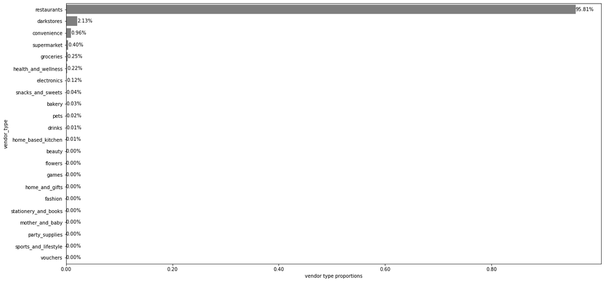

```python
plt.figure(figsize = [20,10])
color = sb.color_palette()[7]
sb.countplot (data=df, y= 'vendor_type' , order = vendor_order, color = color)
plt.xticks (tick_props * n_df, tick_names)
plt.xlabel('vendor type proportions')
#adding its relative frequncy percentage to ech bar
for i in range(vendor_count.shape[0]):
    count = vendor_count[i]
    pct_string = '{:0.2f}%'.format(100*count/n_df)
    plt.text(count+1, i, pct_string, va = 'center');
```

Since about 96% of orders were generated through restaurans followed by 2% Darkstores and 1% the other stores, vendor types are devided into three main/top channels: restaurants and darkstores and all the others being categorised as "shops".

```python
# creating different table names for three categories
df_rest = df[df['vendor_type'] == 'restaurants']
df_dark = df[df['vendor_type'] == 'darkstores']
df_shops = df[(df['vendor_type'] != 'darkstores') & (df['vendor_type'] != 'restaurants')]
```

### Customer behaviour in all three channels are plotted

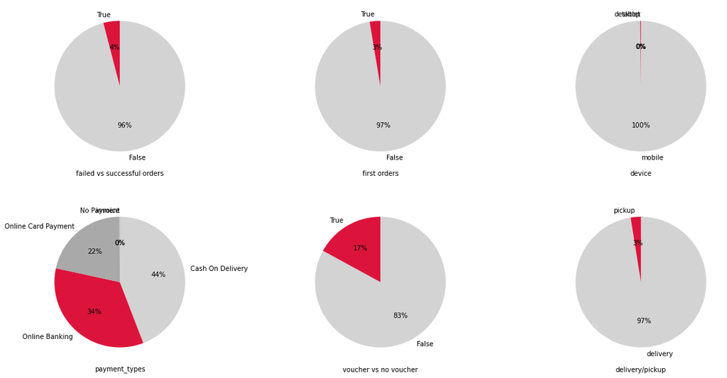

```python
# in restaurants:
plt.figure(figsize = [20,10])
colors = ["lightgray", "crimson", "darkgray"]

plt.subplot (2, 3, 1)
failed_order = df_rest.is_failed_order.value_counts()
plt.pie(failed_order, labels = failed_order.index, startangle = 90, counterclock =False, colors = colors, autopct='%1.f%%');
plt.xlabel('failed vs successful orders')



plt.subplot(2,3,2)
first_order = df_rest.is_first_order.value_counts()
plt.pie(first_order, labels = failed_order.index, startangle = 90, counterclock =False, colors = colors, autopct='%1.f%%');
plt.xlabel('first orders');


plt.subplot(2,3,3)
device = df_rest.device.value_counts()
plt.pie(device, labels = device.index, startangle = 90, counterclock =False, colors = colors, autopct='%1.f%%');
plt.xlabel('device')


plt.subplot(2,3,4)
payment_type = df_rest.payment_type.value_counts()
plt.pie(payment_type, labels = payment_type.index, startangle = 90, counterclock =False, colors = colors, autopct='%1.f%%');
plt.xlabel('payment_types')


plt.subplot(2,3,5)
voucher = df_rest.is_voucher_used.value_counts()
plt.pie(voucher, labels = voucher.index, startangle = 90, counterclock =False, colors = colors, autopct='%1.f%%');
plt.xlabel('voucher vs no voucher');

plt.subplot(2,3,6)
delivery_status = df_rest.delivery_pickup.value_counts()
plt.pie(delivery_status, labels = delivery_status.index, startangle = 90, counterclock =False, colors = colors, autopct='%1.f%%');
plt.xlabel('delivery/pickup');
```

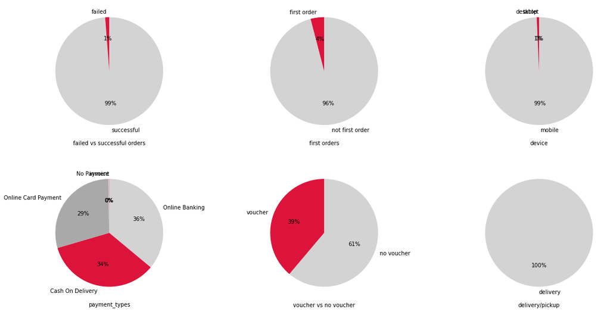

```python
# the same thing for darkstores
plt.figure(figsize = [20,10])
colors = ["lightgray", "crimson", "darkgray"]

plt.subplot (2, 3, 1)
failed_order = df_dark.is_failed_order.value_counts()
plt.pie(failed_order, labels = ['successful', 'failed'], startangle = 90, counterclock =False, colors = colors, autopct='%1.f%%');
plt.xlabel('failed vs successful orders')



plt.subplot(2,3,2)
first_order = df_dark.is_first_order.value_counts()
plt.pie(first_order, labels = ['not first order', 'first order'], startangle = 90, counterclock =False, colors = colors, autopct='%1.f%%');
plt.xlabel('first orders');


plt.subplot(2,3,3)
device = df_dark.device.value_counts()
plt.pie(device, labels = device.index, startangle = 90, counterclock =False, colors = colors, autopct='%1.f%%');
plt.xlabel('device')


plt.subplot(2,3,4)
payment_type = df_dark.payment_type.value_counts()
plt.pie(payment_type, labels = payment_type.index, startangle = 90, counterclock =False, colors = colors, autopct='%1.f%%');
plt.xlabel('payment_types')


plt.subplot(2,3,5)
voucher = df_dark.is_voucher_used.value_counts()
plt.pie(voucher, labels = ['no voucher', 'voucher'], startangle = 90, counterclock =False, colors = colors, autopct='%1.f%%');
plt.xlabel('voucher vs no voucher')

plt.subplot(2,3,6)
delivery_status = df_dark.delivery_pickup.value_counts()
plt.pie(delivery_status, labels = delivery_status.index, startangle = 90, counterclock =False, colors = colors, autopct='%1.f%%');
plt.xlabel('delivery/pickup');
```

- in Darkstores 99% of orders were successful, only 4% of orders were made by first time shoppers, 99% of them used their mobile phone.
- In terms of payment onine banking, cash on delivery and card payment all had close rates with Online banking being on top.
- 61% of purchases were made through organic customers who didnt use any vouchers to complete their orders.
- 100% of orders were delivered to the customers.

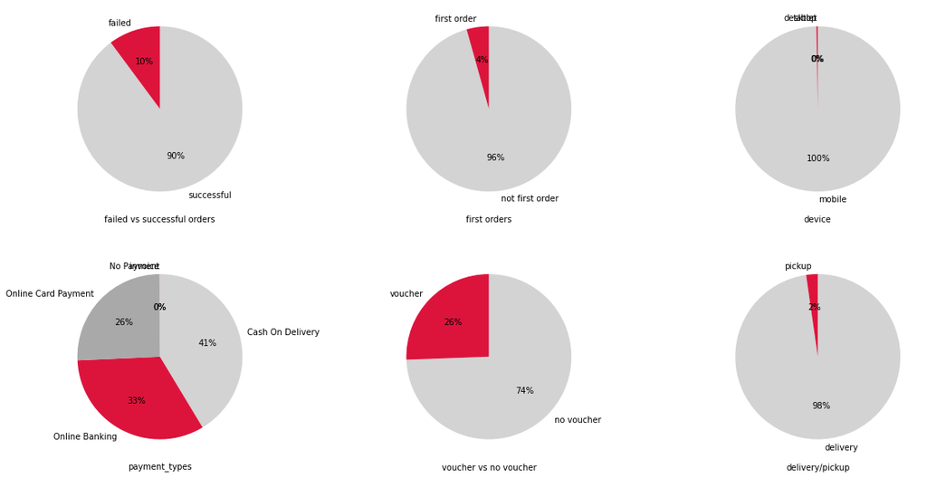

```python
# I will plot that in shops:
plt.figure(figsize = [20,10])
colors = ["lightgray", "crimson", "darkgray"]

plt.subplot (2, 3, 1)
failed_order = df_shops.is_failed_order.value_counts()
plt.pie(failed_order, labels = ['successful', 'failed'], startangle = 90, counterclock =False, colors = colors, autopct='%1.f%%');
plt.xlabel('failed vs successful orders')



plt.subplot(2,3,2)
first_order = df_shops.is_first_order.value_counts()
plt.pie(first_order, labels = ['not first order', 'first order'], startangle = 90, counterclock =False, colors = colors, autopct='%1.f%%');
plt.xlabel('first orders');


plt.subplot(2,3,3)
device = df_shops.device.value_counts()
plt.pie(device, labels = device.index, startangle = 90, counterclock =False, colors = colors, autopct='%1.f%%');
plt.xlabel('device')



plt.subplot(2,3,4)
payment_type = df_shops.payment_type.value_counts()
plt.pie(payment_type, labels = payment_type.index, startangle = 90, counterclock =False, colors = colors, autopct='%1.f%%');
plt.xlabel('payment_types')


plt.subplot(2,3,5)
voucher = df_shops.is_voucher_used.value_counts()
plt.pie(voucher, labels = ['no voucher', 'voucher'], startangle = 90, counterclock =False, colors = colors, autopct='%1.f%%');
plt.xlabel('voucher vs no voucher')

plt.subplot(2,3,6)
delivery_status = df_shops.delivery_pickup.value_counts()
plt.pie(delivery_status, labels = delivery_status.index, startangle = 90, counterclock =False, colors = colors, autopct='%1.f%%');
plt.xlabel('delivery/pickup');
```

- in shops 90% of orders were successful, like dark stores only 4% of orders were made by first time shoppers, mobile is the solo dominant device for its users.
- In terms of payment onine banking, like darkstores but with higher rate cash on delivery stands in the first place followed by online banking and online card payment.
- 74% of purchases were made through organic customers who didnt use any vouchers to complete their orders.

-only 2% of customers picked up their orders and the rest had them delivered.

### now orders distribution in different cities are plotted for the three categories:

```
0.4269197422658349
```

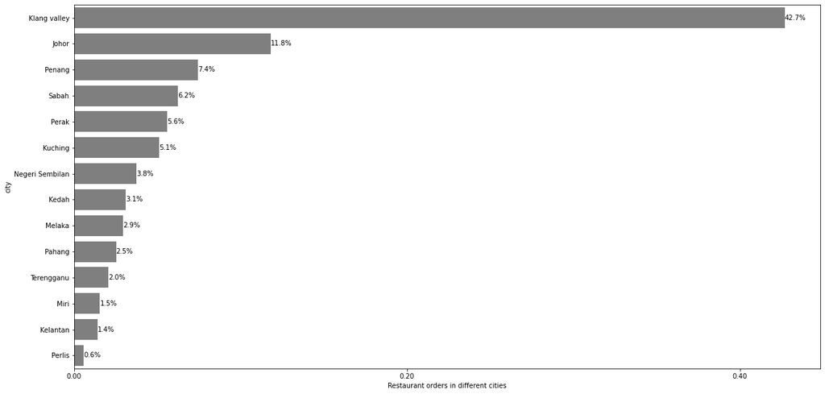

```python
# restaurants:
city_count_rest = df_rest.city.value_counts()
n_df = df_rest.shape[0]
max_city_count_rest = city_count_rest[0]
max_prop = max_city_count_rest / n_df
print(max_prop)

tick_props = np.arange (0, max_prop, 0.2)
tick_names = ['{:0.2f}'.format(v) for v in tick_props]
city_order_rest = df_rest['city'].value_counts().index

plt.figure(figsize = [20,10])
color = sb.color_palette()[7]
sb.countplot (data=df_rest, y= 'city' , order = city_order_rest, color = color)
plt.xticks (tick_props * n_df, tick_names)
plt.xlabel('Restaurant orders in different cities')
#adding its relative frequncy percentage to ech bar
for i in range(city_count_rest.shape[0]):
    count = city_count_rest[i]
    pct_string = '{:0.1f}%'.format(100*count/n_df)
    plt.text(count+1, i, pct_string, va = 'center');
```

```
0.6805468680189438
```

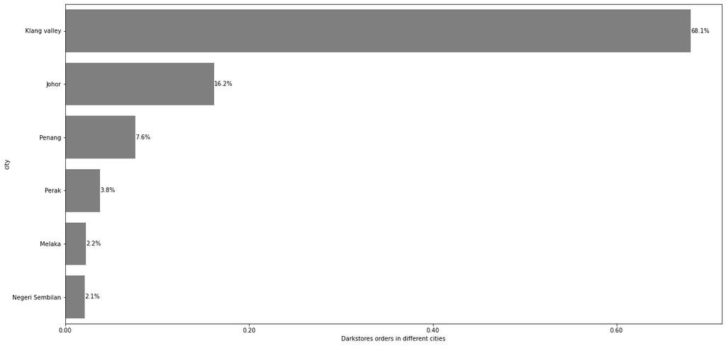

```python
#darkstores:
city_count_dark = df_dark.city.value_counts()
n_df = df_dark.shape[0]
max_city_count_dark = city_count_dark[0]
max_prop = max_city_count_dark/ n_df
print(max_prop)

tick_props = np.arange (0, max_prop, 0.2)
tick_names = ['{:0.2f}'.format(v) for v in tick_props]
city_order_dark = df_dark['city'].value_counts().index

plt.figure(figsize = [20,10])
color = sb.color_palette()[7]
sb.countplot (data=df_dark, y= 'city' , order = city_order_dark, color = color)
plt.xticks (tick_props * n_df, tick_names)
plt.xlabel('Darkstores orders in different cities')
#adding its relative frequncy percentage to ech bar
for i in range(city_count_dark.shape[0]):
    count = city_count_dark[i]
    pct_string = '{:0.1f}%'.format(100*count/n_df)
    plt.text(count+1, i, pct_string, va = 'center');
```

```
0.5059281215264912
```

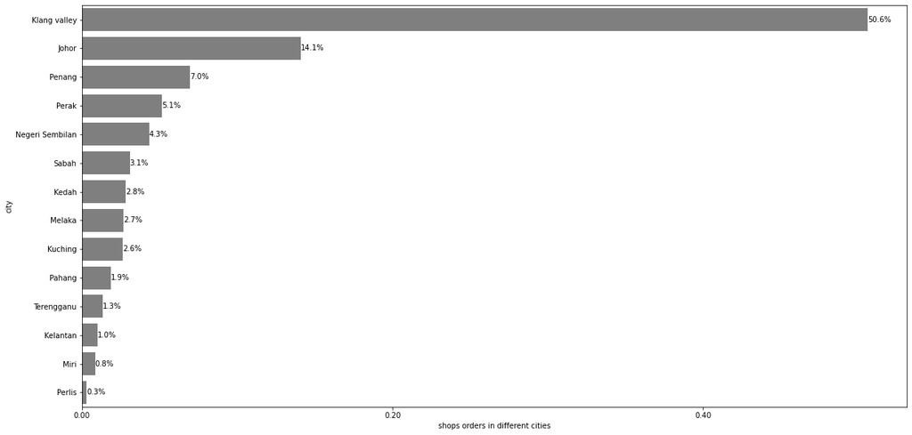

```python
# Shops:
city_count_shops = df_shops.city.value_counts()
n_df = df_shops.shape[0]
max_city_count_shops = city_count_shops[0]
max_prop = max_city_count_shops/ n_df
print(max_prop)

tick_props = np.arange (0, max_prop, 0.2)
tick_names = ['{:0.2f}'.format(v) for v in tick_props]
city_order_shops = df_shops['city'].value_counts().index

plt.figure(figsize = [20,10])
color = sb.color_palette()[7]
sb.countplot (data=df_shops, y= 'city' , order = city_order_shops, color = color)
plt.xticks (tick_props * n_df, tick_names)
plt.xlabel('shops orders in different cities')
#adding its relative frequncy percentage to ech bar
for i in range(city_count_shops.shape[0]):
    count = city_count_shops[i]
    pct_string = '{:0.1f}%'.format(100*count/n_df)
    plt.text(count+1, i, pct_string, va = 'center');
```

### Now, I would like to see top hours where orders where made in those three categories:

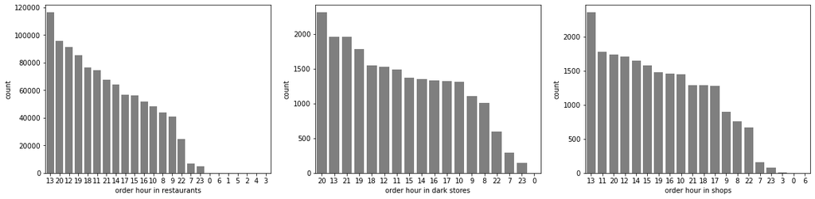

```python
plt.figure(figsize = [20,10])

plt.subplot (2, 3, 1)
color = sb.color_palette()[7]
hour_count = df_rest['order_hour'].value_counts().index
sb.countplot (data=df_rest, x= 'order_hour' , order = hour_count, color = color)
plt.xlabel('order hour in restaurants')


plt.subplot (2, 3, 2)
color = sb.color_palette()[7]
hour_count = df_dark['order_hour'].value_counts().index
sb.countplot (data=df_dark, x= 'order_hour' , order = hour_count, color = color)
plt.xlabel('order hour in dark stores')


plt.subplot (2, 3, 3)
color = sb.color_palette()[7]
hour_count = df_shops['order_hour'].value_counts().index
sb.countplot (data=df_shops, x= 'order_hour' , order = hour_count, color = color)
plt.xlabel('order hour in shops');
```

- It can be inferred that top order hour for restaurants and shops is lunch time at 1PM, however users prefer to make orders from darkstores at night time around 8pm.

### Next, I want to explore the distribution of money generated in each category:

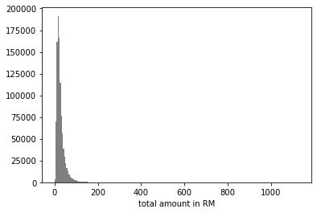

```python
#total amount distibution among restaurant:
bins = np.arange (0, df_rest['total_amount'].max()+5,5)
plt.hist(data= df_rest, x = 'total_amount', bins=bins, color=color);
plt.xlabel('total amount in RM');
```

### since most data is between 0 and 100 I limit the x axes to get closer look at the distribution.

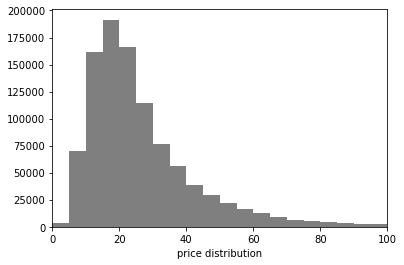

```python
bins = np.arange (0, df_rest['total_amount'].max()+5,5)
plt.hist(data= df_rest, x = 'total_amount', bins=bins, color=color);

plt.xlim(0,100)
plt.xlabel('price distribution');
```

### the distribution is right skewed and all numbers are positive it is best to perfrom log scaling to better understand the disstribution:

```python
#log scaling
pd.options.display.float_format = '{:.2f}'.format
df_rest.total_amount.describe()
```

```
count   1004601.00
mean         27.17
std          19.48
min           0.00
25%          15.30
50%          22.05
75%          32.73
max        1125.41
Name: total_amount, dtype: float64
```

```python
np.log10(df_rest.total_amount.describe())
```

```
count   6.00
mean    1.43
std     1.29
min     -inf
25%     1.18
50%     1.34
75%     1.51
max     3.05
Name: total_amount, dtype: float64
```

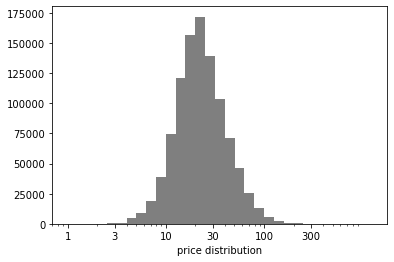

```python
color = sb.color_palette()[7]
bins = 10** np.arange (0, 3.05+0.1, 0.1)
ticks = [ 1, 3, 10, 30, 100, 300]
labels = [ '{}'.format(v) for v in ticks]
plt.hist(data= df_rest, x = 'total_amount', bins=bins, color = color);
plt.xscale('log')
plt.xticks(ticks, labels)
plt.xlabel('price distribution');
```

### For Darkstores:

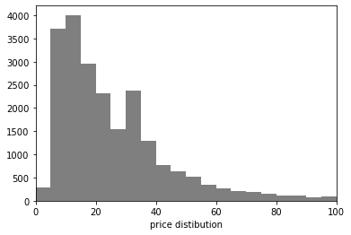

```python
bins = np.arange (0, df_dark['total_amount'].max()+5,5)
plt.hist(data= df_dark, x = 'total_amount', bins=bins, color= color)
plt.xlim(0,100)
plt.xlabel('price distibution');
```

```python
# dark store total amount sidtribution
df_dark.total_amount.describe()
```

```
count   22382.00
mean       27.27
std        25.36
min         0.00
25%        11.61
50%        20.45
75%        33.86
max       454.38
Name: total_amount, dtype: float64
```

```python
np.log10(df_dark.total_amount.describe())
```

```
count   4.35
mean    1.44
std     1.40
min     -inf
25%     1.06
50%     1.31
75%     1.53
max     2.66
Name: total_amount, dtype: float64
```

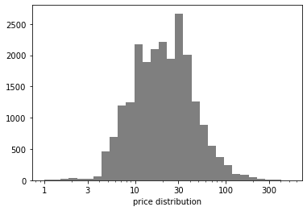

```python
# Log Scaling:
bins = 10** np.arange (0, 2.7+0.09, 0.09)
ticks = [ 1, 3, 10, 30, 100, 300]
labels = [ '{}'.format(v) for v in ticks]
plt.hist(data= df_dark, x = 'total_amount', bins=bins, color= color);
plt.xscale('log')
plt.xticks(ticks, labels)
plt.xlabel('price distribution');
```

### For shops:

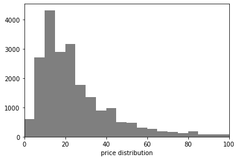

```python
bins = np.arange (0, df_shops['total_amount'].max()+5,5)
plt.hist(data= df_shops, x = 'total_amount', bins=bins, color= color);
plt.xlim(0,100)
plt.xlabel('price distribution');
```

```python
np.log10(df_shops.total_amount.describe())
```

```
count   4.33
mean    1.45
std     1.76
min     -inf
25%     1.08
50%     1.30
75%     1.51
max     3.64
Name: total_amount, dtype: float64
```

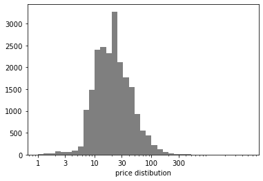

```python
#Log Scaling:
color = sb.color_palette()[7]
bins = 10** np.arange (0, 3.64+0.1, 0.1)
ticks = [ 1, 3, 10, 30, 100, 300]
labels = [ '{}'.format(v) for v in ticks]
plt.hist(data= df_shops, x = 'total_amount', bins=bins, color= color);
plt.xscale('log')
plt.xticks(ticks, labels)
plt.xlabel('price distibution');
```

### Lastly, I would like to see the delivery expedted time in each category:

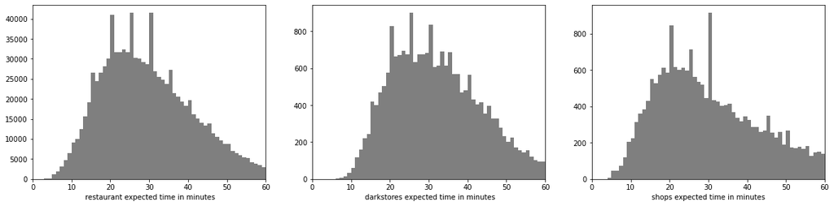

```python
plt.figure(figsize = [20,10])
color = sb.color_palette()[7]


plt.subplot (2, 3, 1)
bins = np.arange (0, df_rest['expected_delivery_in_minutes'].max()+1, 1)
plt.hist(data= df_rest, x = 'expected_delivery_in_minutes', bins=bins, color= color);
plt.xlim(0, 60)
plt.xlabel(' restaurant expected time in minutes')




plt.subplot (2, 3, 2)
bins = np.arange (0, df_dark['expected_delivery_in_minutes'].max()+1, 1)
plt.hist(data= df_dark, x = 'expected_delivery_in_minutes', bins=bins, color= color);
plt.xlim(0, 60)
plt.xlabel(' darkstores expected time in minutes')



plt.subplot (2, 3, 3)
bins = np.arange (0, df_shops['expected_delivery_in_minutes'].max()+1, 1)
plt.hist(data= df_shops, x = 'expected_delivery_in_minutes', bins=bins, color= color);
plt.xlim(0, 60)
plt.xlabel('shops expected time in minutes');
```

### Discuss the distribution(s) of your variable(s) of interest. Were there any unusual points? Did you need to perform any transformations?

> Log scale transformation was perfromed when plotting price distribution. since the plotts were highly right skewed and wouldnt project a clear message on their own.

### Of the features you investigated, were there any unusual distributions? Did you perform any operations on the data to tidy, adjust, or change the form of the data? If so, why did you do this?

> when plotting expected delivery time distribution I realised there are outliers that blocking the dirstribution to be clearly depicted, the xlim was perfromed to narrow down the view and get more clear image in a window of one hour.

## Bivariate Exploration

> In this section, investigate relationships between pairs of variables in your data. Make sure the variables that you cover here have been introduced in some fashion in the previous section (univariate exploration).

```python
# vendor daily order and total amount scatter plot
df_rest.head()
```

|  | order_id | payment_type | city | zone | vendor_type | delivery_pickup | vendor_daily_order_number | total_amount | is_first_order | is_failed_order | is_voucher_used | expected_delivery_in_minutes | device | order_time | order_hour |
| --- | --- | --- | --- | --- | --- | --- | --- | --- | --- | --- | --- | --- | --- | --- | --- |
| 0 | 175893311 | Online Banking | Terengganu | Chukai | restaurants | delivery | 192.00 | 23.17 | False | False | False | 62 | mobile | 2021-03-05 20:27:10+00:00 | 20 |
| 1 | 175893309 | Online Banking | Kedah | Sungai petani | restaurants | delivery | 147.00 | 30.11 | False | False | False | 60 | mobile | 2021-03-05 20:27:10+00:00 | 20 |
| 2 | 175893304 | Online Banking | Klang valley | Ampang | restaurants | delivery | 2654.00 | 39.50 | False | False | False | 42 | mobile | 2021-03-05 20:27:10+00:00 | 20 |
| 3 | 175893308 | Online Banking | NaN | NaN | restaurants | delivery | 752.00 | 131.98 | False | False | False | 30 | mobile | 2021-03-05 20:27:10+00:00 | 20 |
| 4 | 175893305 | Online Banking | Klang valley | Tanjung karang halal | restaurants | delivery | 2701.00 | 16.99 | False | False | False | 20 | mobile | 2021-03-05 20:27:10+00:00 | 20 |

### first I would like to see the relationship between hour that the order placed and and the total amount generated

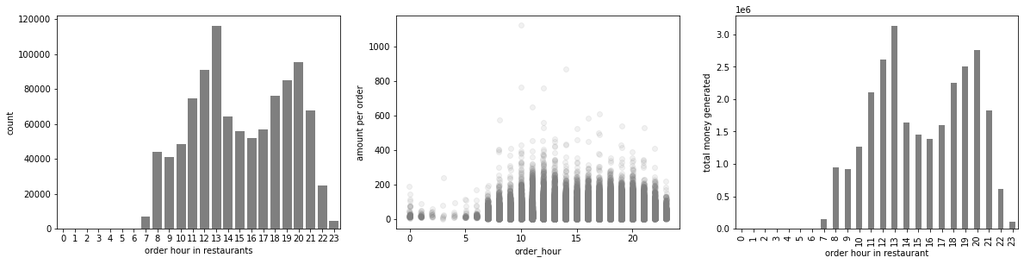

```python
# now we want to know relationship of total orders price in each hour

plt.figure(figsize = [20,10])

plt.subplot (2, 3, 1)
color = sb.color_palette()[7]
sb.countplot (data=df_rest, x= 'order_hour', color = color)
plt.xlabel('order hour in restaurants')

plt.subplot (2, 3, 2)

sb.regplot(data = df_rest, x = 'order_hour', y = 'total_amount', x_jitter = 0.04, scatter_kws = {'alpha' : 1/10}, fit_reg = False, color= color);
plt.xlabel('order_hour')
plt.ylabel('amount per order')

plt.subplot (2, 3, 3)

hour_total = df_rest.groupby('order_hour').total_amount.sum()
hour_total.plot.bar(color= color)
plt.xlabel('order hour in restaurant')
plt.ylabel('total money generated');
```

### No I would like to depict the relationship between hour of order and expecteded delivery time

```python
df_rest[['order_hour','expected_delivery_in_minutes' ]].describe()
```

|  | order_hour | expected_delivery_in_minutes |
| --- | --- | --- |
| count | 1004601.00 | 1004601.00 |
| mean | 15.11 | 29.71 |
| std | 4.05 | 25.37 |
| min | 0.00 | 0.00 |
| 25% | 12.00 | 20.00 |
| 50% | 15.00 | 28.00 |
| 75% | 19.00 | 37.00 |
| max | 23.00 | 22132.00 |

```python
df_rest[df_rest['expected_delivery_in_minutes']== 22132.0].index
```

```
Int64Index([706249], dtype='int64')
```

```python
# there seems to be one point with abnormal value, lets drop that one point.
df_rest.drop(df_rest[df_rest['expected_delivery_in_minutes']== 22132.0].index, inplace=True)
```

```python
#check if it is successfully dropped.
df_rest[df_rest['expected_delivery_in_minutes']== 22132.0]
```

|  | order_id | payment_type | city | zone | vendor_type | delivery_pickup | vendor_daily_order_number | total_amount | is_first_order | is_failed_order | is_voucher_used | expected_delivery_in_minutes | device | order_time | order_hour |
| --- | --- | --- | --- | --- | --- | --- | --- | --- | --- | --- | --- | --- | --- | --- | --- |

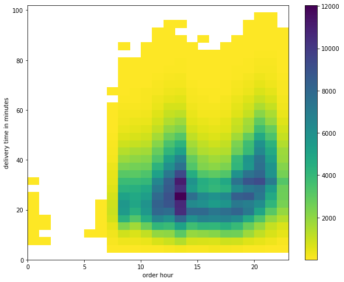

```python
plt.figure(figsize = [10,8])
bin_x = np.arange(0, 23+1, 1)
bin_y = np.arange (0, 100+3, 3)
plt.hist2d(data = df_rest, x= 'order_hour', y = 'expected_delivery_in_minutes', cmin= 5, cmap = 'viridis_r', bins = [bin_x, bin_y]);
plt.colorbar()
plt.xlabel('order hour')
plt.ylabel('delivery time in minutes');
```

- As expected the most deliveries are taking place during lunch and about 25 minutes wait. as we move toward dinner time dthere is few orders with less that 10 minutes although we have more faster deliveries in lunch time.

### Next:

- Then I would like to categories hours in a day into 6 categories to facilitate the comparison:

  6 categories are:

  ```
        'after_midnight', 'early_breakfast', 'brunch', 'lunch', 'evening_snack', 'dinner'
  ```

- After, I will explore the fail rate and successful rate among those categories and take a deeper lok at the distribution of expedted delivery time in them.

```python
bins = np.arange(0, 28, 4)
# categories are labled like this
bins_names = ['after_midnight', 'early_breakfast', 'brunch', 'lunch', 'evening_snack', 'dinner']
df_rest['time_segment'] = pd.cut(df['order_hour'], bins,  labels=bins_names, right=False)
```

```python
# this is a finction that generates distibution of failed/successful orders in unit % across all categories:
def with_hue(plot, feature, Number_of_categories, hue_categories):
    a = [p.get_height() for p in plot.patches]
    patch = [p for p in plot.patches]
    for i in range(Number_of_categories):
        total = feature.value_counts().values[i]
        for j in range(hue_categories):
            percentage = '{:.1f}%'.format(100 * a[(j*Number_of_categories + i)]/total)
            x = patch[(j*Number_of_categories + i)].get_x() + patch[(j*Number_of_categories + i)].get_width() / 2 - 0.15
            y = patch[(j*Number_of_categories + i)].get_y() + patch[(j*Number_of_categories + i)].get_height()
            ax.annotate(percentage, (x, y), size = 12)
    plt.show()

def without_hue(plot, feature):
    total = len(feature)
    for p in plot.patches:
        percentage = '{:.1f}%'.format(100 * p.get_height()/total)
        x = p.get_x() + p.get_width() / 2 - 0.05
        y = p.get_y() + p.get_height()
        ax.annotate(percentage, (x, y), size = 12)
    plt.show()
```

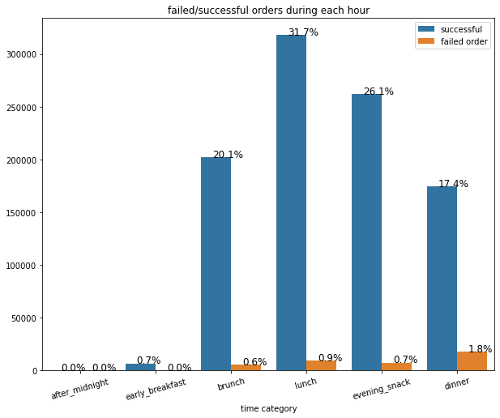

```python
plt.figure(figsize = [10, 8])


ax = sb.countplot(data = df_rest, x = 'time_segment', hue = 'is_failed_order', dodge = True)
ax.set_title('failed/successful orders during each hour')
ax.set(xlabel = 'time category', ylabel ='')
ax.legend( ['successful','failed order']);
plt.xticks(rotation =15);



without_hue(ax, df_rest.time_segment)
```

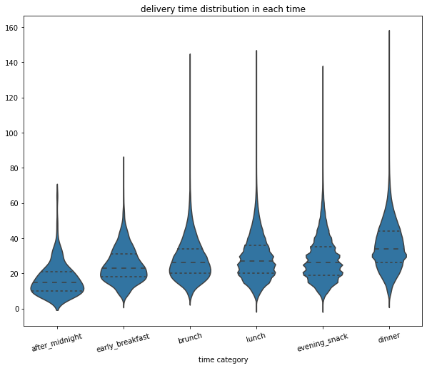

```python
# take a look at distibution of delivery time in each category:
plt.figure(figsize = [10, 8])
base_color = sb.color_palette()[0]
ax = sb.violinplot(data = df_rest, x ='time_segment', y = 'expected_delivery_in_minutes', color = base_color, inner = 'quartile')
ax.set_title('delivery time distribution in each time')
ax.set(xlabel = 'time category', ylabel = '')
plt.xticks( rotation =15);
```

### Did you observe any interesting relationships between the other features (not the main feature(s) of interest)?

> total money generated is still hig during dinner although the fail rates are also high. There is a potential to generate more money if delivery time can be decreased, in next section I will explore wether hiring more riders can solve the problem if delivery is preferred over pickup in those times.

## Multivariate Exploration

- Now, three variables od order hour, expected delivery time and status of orders will be explored.
- Also the preferrance of delivery time i.e. delivery/pickup, time and status of orders will be analysed.

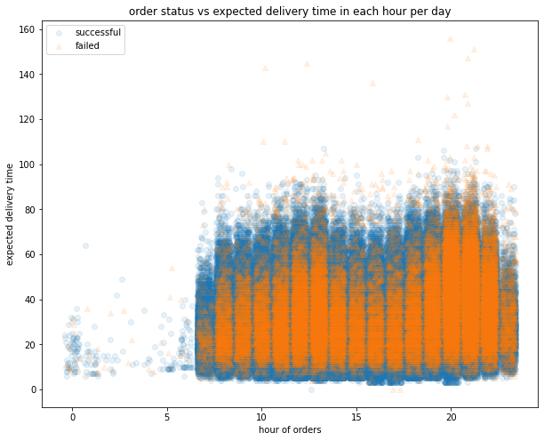

```python
plt.figure(figsize = [10, 8])

ttype_markers = [[False, 'o'],
                 [True, '^']]
for ttype, marker in ttype_markers:
    plot_data =df_rest.loc[df_rest['is_failed_order'] == ttype]
    sb.regplot(data =plot_data, x = 'order_hour' , y = 'expected_delivery_in_minutes', x_jitter = 0.4 , fit_reg = False, scatter_kws={'alpha':0.1}, marker =marker)

plt.xlabel ('hour of orders')
plt.ylabel('expected delivery time')
plt.legend (['successful', 'failed'])
plt.title('order status vs expected delivery time in each hour per day');
```

- As expected failed orders increase during dinner time, however highest demand in orders lies within lunch time and decrease during dinner.

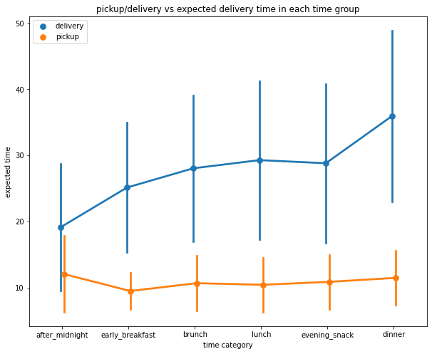

```python
plt.figure(figsize = [10, 8])
sb.pointplot( data = df_rest, x ='time_segment', y = 'expected_delivery_in_minutes', hue = 'delivery_pickup',
            ci = 'sd', linestyle = "", dodge = True)
plt.xlabel ('time category')
plt.ylabel('expected time')
plt.legend ()
plt.title('pickup/delivery vs expected delivery time in each time group');
```

### Talk about some of the relationships you observed in this part of the investigation. Were there features that strengthened each other in terms of looking at your feature(s) of interest?

> - failed orders increase during dinner time, although as mentioned before highest demand in orders lies within lunch time and decrease during dinner.

### Were there any interesting or surprising interactions between features?

> - Pick up time is drastically less than delivery, as mentioned in part one, only account for 3 % of orders. Nevertheless pickup trend doesn't change from lunch to dinner. Interesting point is that customers are more inclined toward pickup after midnight compared to other time segments.